# Offsite Data prelim analysis

Hardy Griesbauer

18/03/2020

### Administrative summaries

Trial objective is to study the effects of regional climate, soil moisture regime, and provenance climate on survival and early growth of western redcedar, Douglas-fir, and western larch.

Four BGC units were selected, and within each BGC unit, we identified four sites spanning soil moisture regimes ranging from subxeric to subhygric. In addition, in the SBSwk1, we located a fifth site (xeric). We used the term *plot* to denote each BGC unit/soil moisture regime combination. Therefore, we had a total of 17 plots (4 BGC units x 4 soil moisture regime + 1 additional soil moisture regime in SBSwk1).

We planted cedar and Douglas-fir seedlings from three different provenance climates (seedlots) and larch from two different provenance climates. Therefore, we had 8 combinations of species/seedlot.

At each plot, we planted 20 replicates of each species/seedlot combination in a randomized block design. Each block had had three rows (one for each species, selected at random), and each seedlot was planted in random order along each row. Alvin Yanchuk advised the experimental design.

**Measurements** We measured growth, root collar, and vigour in 2015 and 2018. For larch and Douglas-fir, we used leader growth to determine seedling height in other years.

Vigour, root collar, and forest health factors in this dataset are from 2018 measurements.

**Number of trees planted per seedlot**

```r
## Number of trees planted by species and seedlot
X %>%
  group_by(Species,Seedlot) %>%
  summarise(`Number Planted`=n())
```

```
## # A tibble: 8 x 3
## # Groups:   Species [3]
##   Species Seedlot `Number Planted`
##   <chr>   <chr>              <int>
## 1 Cw      A                    334
## 2 Cw      B                    336
## 3 Cw      C                    334
## 4 Fdi     A                    335
## 5 Fdi     B                    334
## 6 Fdi     C                    335
## 7 Lw      A                    335
## 8 Lw      B                    336
```

**Number of Site and soil moisture regime within site/BGC** As previously described, we planted 20 seedlings of each species/seedlot combination (8 combinations in total, see above) at each plot.

Only exception: SX plot in Burns Lake, because we couldn’t find enough plantable spots.

```r
X %>%
  group_by(Site,BGC,SMR) %>%
  summarise(`Number Planted`=n())
```

```
## # A tibble: 17 x 4
## # Groups:   Site, BGC [4]
##    Site       BGC    SMR   `Number Planted`
##    <chr>      <chr>  <fct>            <int>
##  1 Bear Lake  SBSwk1 SH                 160
##  2 Bear Lake  SBSwk1 M                  160
##  3 Bear Lake  SBSwk1 SM                 160
##  4 Bear Lake  SBSwk1 SX                 160
##  5 Bear Lake  SBSwk1 X                  160
##  6 Burns Lake SBSdk  SH                 159
##  7 Burns Lake SBSdk  M                  160
##  8 Burns Lake SBSdk  SM                 160
##  9 Burns Lake SBSdk  SX                 120
## 10 Pidherny   SBSdw3 SH                 160
## 11 Pidherny   SBSdw3 M                  160
## 12 Pidherny   SBSdw3 SM                 160
## 13 Pidherny   SBSdw3 SX                 160
## 14 Smithers   SBSmc2 SH                 160
## 15 Smithers   SBSmc2 M                  160
## 16 Smithers   SBSmc2 SM                 160
## 17 Smithers   SBSmc2 SX                 160
```

### Survival

Survival was really low in this trial, as we experienced a strong drought that spring.

Summarize 2018 survival by species/seedlot:

```r
X %>%
  group_by(Species,Seedlot) %>%
  summarise(dead=sum(Vigour==3,na.rm=T),
            live=sum(Vigour!=3,na.rm=T)) %>%
  mutate(`survival %`=round(live/(dead+live),2))
```

```
## # A tibble: 8 x 5
## # Groups:   Species [3]
##   Species Seedlot  dead  live `survival %`
##   <chr>   <chr>   <int> <int>        <dbl>
## 1 Cw      A         221   110         0.33
## 2 Cw      B         276    60         0.18
## 3 Cw      C         287    47         0.14
## 4 Fdi     A         193   141         0.42
## 5 Fdi     B         179   154         0.46
## 6 Fdi     C         214   120         0.36
## 7 Lw      A         215   118         0.35
## 8 Lw      B         184   151         0.45
```

We see that over half of all species/seedlot combinations died by 2018.

Look at survival by BGC unit:

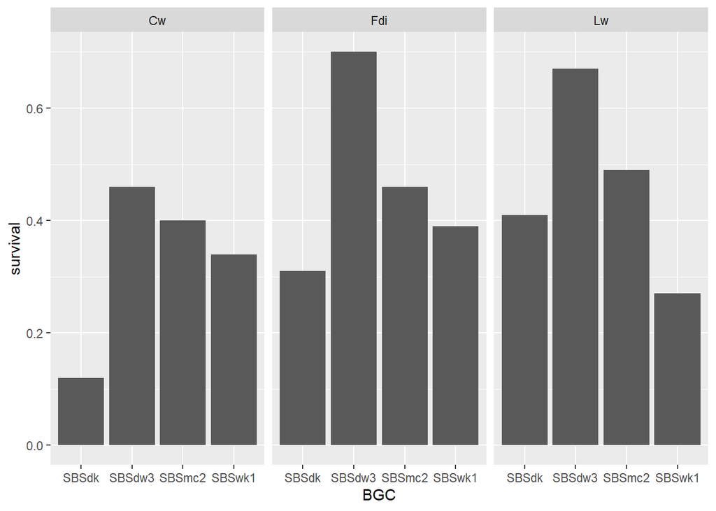

```r
X %>%
  group_by(Species,Seedlot,BGC) %>%
  summarise(dead=sum(Vigour==3,na.rm=T),
            live=sum(Vigour!=3,na.rm=T)) %>%
  mutate(`survival`=round(live/(dead+live),2)) %>%

  # plotting
  ggplot()+
  aes(x=BGC,y=`survival`,group="Seedlot")+
  geom_bar(stat="Identity",position = "dodge")+
  facet_wrap(~Species)
```

Can see that all species had highest survival in SBSdw3.